# EBENEZER MARADESA

## Project 3

## Communicate Data Findings

### PART I - EXPLORATORY DATA VISUALIZATION

### DATASET: Diabetes Health Indicators Dataset

- Introduction
- Preliminary Wrangling
- Univariate Exploration
- Bivariate Exploration
- Multivariate Exploration
- Conclusions

# Introduction

The Diabetes Health Indicators Dataset was gotten from, and can be found [here on Kaggle](https://kaggle.com/datasets/alexteboul/diabetes-health-indicators-dataset). It was derived/engineered by Alex Teboul from a series of datasets of the Behavioral Risk Factor Surveillance System (BRFSS). Specifically, `the diabetes_012_health_indicators_BRFSS2015.csv` is used here.

It contains 250,000+ records and 22 variables/columns (21 features and 1 target). The columns are summarized thus:

| Column Name | Description | Values |
| --- | --- | --- |
| Diabetes_012 | Diabetes Status | 0 - no diabetes 1 - prediabetes 2 - diabetes |
| HighBP | High Blood Pressure | 0 - no 1 - yes |
| HighChol | High Cholesterol | 0 - no 1 - yes |
| CholCheck | Cholesterol check in last 5 years | 0 - no 1 - yes |
| BMI | Body Mass Index | (numerical variables) |
| Smoker | smoked >=100 cigarettes(5 packs) in entire life | 0 - no 1 - yes |
| Stroke | Ever had a stroke? | 0 - no 1 - yes |
| HeartDiseaseorAttack | Ever had coronary heart disease (CHD) or myocardial infarction (MI)? | 0 - no 1 - yes |
| PhysActivity | Physical activity in past 30 days, not including job | 0 - no 1 - yes |
| Fruits | Consume fruit 1 or more times per day | 0 - no 1 - yes |
| Veggies | Consume vegetables 1 or more times per day | 0 - no 1 - yes |
| HvyAlcoholConsump | Heavy drinkers(adult men or women having more than 14 or 7 drinks/week respectively) | 0 - no 1 - yes |
| AnyHealthCare | Have any form of healthcare coverage | 0 - no 1 - yes |
| NoDocbcCost | Unable to see doctor due to cost any time in past 12 months | 0 - no 1 - yes |
| GenHlth | General Health rating | 1 - excellent 2 - very good 3 - good 4 - fair 5 - poor |
| MentHlth | No. of days of poor mental health in past 30 days | (number between 0 and 30) |
| PhysHlth | No. of days of poor physical health in past 30 days | (number between 0 and 30) |
| DiffWalk | Serious difficulty walking or climbing stairs? | 0 - no 1 - yes |
| Sex | Male or female? | 0 - female 1 - male |
| Age | 13-level age category | 1 - 18-24 2 - 25-29 3 - 30-34 ... 12 - 75-79 13 - >=80 |
| Education | Level of Education | 1 - Kindergarten/None 2 - Elementary (Grades 1-8) 3 - Some High School (Grades 9-11) 4 - High School Graduate(Grade 12 or GED) 5 - Some College (1-3 yrs) or Technical School 6 - College (1-3 yrs) Grad… |
| Income | Income($) scale | 1 - <10,000 5 - <35000 8 - >=75000 |

**This Part I document contains Exploratory Data Visualizations performed on this dataset.**

# Preliminary Wrangling

### Import Libraries

```python
# import all packages and set plots to be embedded inline
import numpy as np
import pandas as pd
import matplotlib.pyplot as plt
import seaborn as sns
sns.set_style('darkgrid')

%matplotlib inline
```

### Load in Dataset

TODO:

> Load the dataset into `diabetes_df`

> Get summary information on the dataset

```python
# load data

diabetes_df = pd.read_csv('data/diabetes_012_health_indicators_BRFSS2015.csv')
```

```python
# summary/overview

print(diabetes_df.shape)
print(diabetes_df.info())
```

```
(253680, 22)
<class 'pandas.core.frame.DataFrame'>
RangeIndex: 253680 entries, 0 to 253679
Data columns (total 22 columns):
 #   Column                Non-Null Count   Dtype
---  ------                --------------   -----
 0   Diabetes_012          253680 non-null  float64
 1   HighBP                253680 non-null  float64
 2   HighChol              253680 non-null  float64
 3   CholCheck             253680 non-null  float64
 4   BMI                   253680 non-null  float64
 5   Smoker                253680 non-null  float64
 6   Stroke                253680 non-null  float64
 7   HeartDiseaseorAttack  253680 non-null  float64
 8   PhysActivity          253680 non-null  float64
```

[output cut: 16 more lines]

```python
diabetes_df.head(10)
```

|  | Diabetes_012 | HighBP | HighChol | CholCheck | BMI | Smoker | Stroke | HeartDiseaseorAttack | PhysActivity | Fruits | ... | AnyHealthcare | NoDocbcCost | GenHlth | MentHlth | PhysHlth | DiffWalk | Sex | Age | Education | Income |
| --- | --- | --- | --- | --- | --- | --- | --- | --- | --- | --- | --- | --- | --- | --- | --- | --- | --- | --- | --- | --- | --- |
| 0 | 0.0 | 1.0 | 1.0 | 1.0 | 40.0 | 1.0 | 0.0 | 0.0 | 0.0 | 0.0 | ... | 1.0 | 0.0 | 5.0 | 18.0 | 15.0 | 1.0 | 0.0 | 9.0 | 4.0 | 3.0 |
| 1 | 0.0 | 0.0 | 0.0 | 0.0 | 25.0 | 1.0 | 0.0 | 0.0 | 1.0 | 0.0 | ... | 0.0 | 1.0 | 3.0 | 0.0 | 0.0 | 0.0 | 0.0 | 7.0 | 6.0 | 1.0 |
| 2 | 0.0 | 1.0 | 1.0 | 1.0 | 28.0 | 0.0 | 0.0 | 0.0 | 0.0 | 1.0 | ... | 1.0 | 1.0 | 5.0 | 30.0 | 30.0 | 1.0 | 0.0 | 9.0 | 4.0 | 8.0 |
| 3 | 0.0 | 1.0 | 0.0 | 1.0 | 27.0 | 0.0 | 0.0 | 0.0 | 1.0 | 1.0 | ... | 1.0 | 0.0 | 2.0 | 0.0 | 0.0 | 0.0 | 0.0 | 11.0 | 3.0 | 6.0 |
| 4 | 0.0 | 1.0 | 1.0 | 1.0 | 24.0 | 0.0 | 0.0 | 0.0 | 1.0 | 1.0 | ... | 1.0 | 0.0 | 2.0 | 3.0 | 0.0 | 0.0 | 0.0 | 11.0 | 5.0 | 4.0 |
| 5 | 0.0 | 1.0 | 1.0 | 1.0 | 25.0 | 1.0 | 0.0 | 0.0 | 1.0 | 1.0 | ... | 1.0 | 0.0 | 2.0 | 0.0 | 2.0 | 0.0 | 1.0 | 10.0 | 6.0 | 8.0 |
| 6 | 0.0 | 1.0 | 0.0 | 1.0 | 30.0 | 1.0 | 0.0 | 0.0 | 0.0 | 0.0 | ... | 1.0 | 0.0 | 3.0 | 0.0 | 14.0 | 0.0 | 0.0 | 9.0 | 6.0 | 7.0 |
| 7 | 0.0 | 1.0 | 1.0 | 1.0 | 25.0 | 1.0 | 0.0 | 0.0 | 1.0 | 0.0 | ... | 1.0 | 0.0 | 3.0 | 0.0 | 0.0 | 1.0 | 0.0 | 11.0 | 4.0 | 4.0 |
| 8 | 2.0 | 1.0 | 1.0 | 1.0 | 30.0 | 1.0 | 0.0 | 1.0 | 0.0 | 1.0 | ... | 1.0 | 0.0 | 5.0 | 30.0 | 30.0 | 1.0 | 0.0 | 9.0 | 5.0 | 1.0 |
| 9 | 0.0 | 0.0 | 0.0 | 1.0 | 24.0 | 0.0 | 0.0 | 0.0 | 0.0 | 0.0 | ... | 1.0 | 0.0 | 2.0 | 0.0 | 0.0 | 0.0 | 1.0 | 8.0 | 4.0 | 3.0 |

10 rows × 22 columns

```python
# checking to comfirm unique values in each column

diabetes_df.nunique()
```

```
Diabetes_012             3
HighBP                   2
HighChol                 2
CholCheck                2
BMI                     84
Smoker                   2
Stroke                   2
HeartDiseaseorAttack     2
PhysActivity             2
Fruits                   2
Veggies                  2
HvyAlcoholConsump        2
AnyHealthcare            2
NoDocbcCost              2
GenHlth                  5
MentHlth                31
PhysHlth                31
DiffWalk                 2
Sex                      2
Age                     13
Education                6
Income                   8
dtype: int64
```

```python
# checking for missing values
diabetes_df.isnull().any()
```

```
Diabetes_012            False
HighBP                  False
HighChol                False
CholCheck               False
BMI                     False
Smoker                  False
Stroke                  False
HeartDiseaseorAttack    False
PhysActivity            False
Fruits                  False
Veggies                 False
HvyAlcoholConsump       False
AnyHealthcare           False
NoDocbcCost             False
GenHlth                 False
MentHlth                False
PhysHlth                False
DiffWalk                False
Sex                     False
Age                     False
Education               False
Income                  False
dtype: bool
```

```python
# check for duplicates
diabetes_df[diabetes_df.duplicated()]
```

|  | Diabetes_012 | HighBP | HighChol | CholCheck | BMI | Smoker | Stroke | HeartDiseaseorAttack | PhysActivity | Fruits | ... | AnyHealthcare | NoDocbcCost | GenHlth | MentHlth | PhysHlth | DiffWalk | Sex | Age | Education | Income |
| --- | --- | --- | --- | --- | --- | --- | --- | --- | --- | --- | --- | --- | --- | --- | --- | --- | --- | --- | --- | --- | --- |
| 1242 | 2.0 | 1.0 | 1.0 | 1.0 | 27.0 | 1.0 | 0.0 | 0.0 | 0.0 | 0.0 | ... | 1.0 | 0.0 | 5.0 | 0.0 | 30.0 | 1.0 | 0.0 | 10.0 | 4.0 | 5.0 |
| 1563 | 0.0 | 0.0 | 0.0 | 1.0 | 21.0 | 1.0 | 0.0 | 0.0 | 1.0 | 1.0 | ... | 1.0 | 0.0 | 1.0 | 0.0 | 0.0 | 0.0 | 0.0 | 4.0 | 6.0 | 8.0 |
| 2700 | 0.0 | 0.0 | 0.0 | 1.0 | 32.0 | 0.0 | 0.0 | 0.0 | 1.0 | 1.0 | ... | 1.0 | 0.0 | 2.0 | 0.0 | 0.0 | 0.0 | 0.0 | 5.0 | 6.0 | 8.0 |
| 3160 | 0.0 | 0.0 | 0.0 | 1.0 | 21.0 | 0.0 | 0.0 | 0.0 | 1.0 | 1.0 | ... | 1.0 | 0.0 | 1.0 | 0.0 | 0.0 | 0.0 | 0.0 | 4.0 | 6.0 | 8.0 |
| 3332 | 0.0 | 0.0 | 0.0 | 1.0 | 24.0 | 0.0 | 0.0 | 0.0 | 1.0 | 1.0 | ... | 1.0 | 0.0 | 1.0 | 0.0 | 0.0 | 0.0 | 1.0 | 9.0 | 6.0 | 8.0 |
| ... | ... | ... | ... | ... | ... | ... | ... | ... | ... | ... | ... | ... | ... | ... | ... | ... | ... | ... | ... | ... | ... |
| 253492 | 2.0 | 1.0 | 1.0 | 1.0 | 33.0 | 0.0 | 0.0 | 0.0 | 1.0 | 1.0 | ... | 1.0 | 0.0 | 3.0 | 0.0 | 0.0 | 0.0 | 1.0 | 9.0 | 6.0 | 6.0 |
| 253550 | 0.0 | 0.0 | 0.0 | 1.0 | 25.0 | 0.0 | 0.0 | 0.0 | 1.0 | 1.0 | ... | 1.0 | 0.0 | 1.0 | 0.0 | 0.0 | 0.0 | 0.0 | 7.0 | 6.0 | 8.0 |
| 253563 | 0.0 | 0.0 | 1.0 | 1.0 | 24.0 | 1.0 | 0.0 | 0.0 | 1.0 | 1.0 | ... | 1.0 | 0.0 | 2.0 | 0.0 | 0.0 | 0.0 | 1.0 | 8.0 | 6.0 | 8.0 |
| 253597 | 0.0 | 0.0 | 0.0 | 1.0 | 24.0 | 0.0 | 0.0 | 0.0 | 1.0 | 1.0 | ... | 1.0 | 0.0 | 2.0 | 0.0 | 0.0 | 0.0 | 0.0 | 5.0 | 6.0 | 8.0 |
| 253638 | 0.0 | 0.0 | 0.0 | 1.0 | 24.0 | 0.0 | 0.0 | 0.0 | 1.0 | 1.0 | ... | 1.0 | 0.0 | 2.0 | 0.0 | 0.0 | 0.0 | 1.0 | 1.0 | 4.0 | 6.0 |

23899 rows × 22 columns

### Assess

- Variables are floats that should be ints
- Most variables are categorical

### Clean

Since the majority are categorical or discrete, it is best to convert them to int and discard the .0's, so they don't mess up axes labels. Only the BMI will be left as floats

##### *Define*

Convert floats to ints

##### *Code*

```python
cols_to_int = ['Diabetes_012', 'HighBP', 'HighChol', 'CholCheck', 'Smoker',
       'Stroke', 'HeartDiseaseorAttack', 'PhysActivity', 'Fruits', 'Veggies',
       'HvyAlcoholConsump', 'AnyHealthcare', 'NoDocbcCost', 'GenHlth',
       'MentHlth', 'PhysHlth', 'DiffWalk', 'Sex', 'Age', 'Education',
       'Income']     # list of columns to be converted to ints

for col in cols_to_int:
    diabetes_df[col] = diabetes_df[col].astype(int)
```

##### *Test*

```python
diabetes_df.info()
```

```
<class 'pandas.core.frame.DataFrame'>
RangeIndex: 253680 entries, 0 to 253679
Data columns (total 22 columns):
 #   Column                Non-Null Count   Dtype
---  ------                --------------   -----
 0   Diabetes_012          253680 non-null  int64
 1   HighBP                253680 non-null  int64
 2   HighChol              253680 non-null  int64
 3   CholCheck             253680 non-null  int64
 4   BMI                   253680 non-null  float64
 5   Smoker                253680 non-null  int64
 6   Stroke                253680 non-null  int64
 7   HeartDiseaseorAttack  253680 non-null  int64
 8   PhysActivity          253680 non-null  int64
 9   Fruits                253680 non-null  int64
 10  Veggies               253680 non-null  int64
 11  HvyAlcoholConsump     253680 non-null  int64
 12  AnyHealthcare         253680 non-null  int64
 13  NoDocbcCost           253680 non-null  int64
 14  GenHlth               253680 non-null  int64
 15  MentHlth              253680 non-null  int64
 16  PhysHlth              253680 non-null  int64
 17  DiffWalk              253680 non-null  int64
 18  Sex                   253680 non-null  int64
 19  Age                   253680 non-null  int64
 20  Education             253680 non-null  int64
 21  Income                253680 non-null  int64
dtypes: float64(1), int64(21)
memory usage: 42.6 MB
```

Most of the variables are categorical.

##### *Define*

BMI is not categorical, but is of Numerical Continuous type.

Every other row is row Categorical, with Diab_012, GenHlth, Age, Education, and Income being Ordinal, and all others Nominal.

##### *Code*

Convert the cateogrical variables into appropriate types.

```python
# view columns
diabetes_df.columns
```

```
Index(['Diabetes_012', 'HighBP', 'HighChol', 'CholCheck', 'BMI', 'Smoker',
       'Stroke', 'HeartDiseaseorAttack', 'PhysActivity', 'Fruits', 'Veggies',
       'HvyAlcoholConsump', 'AnyHealthcare', 'NoDocbcCost', 'GenHlth',
       'MentHlth', 'PhysHlth', 'DiffWalk', 'Sex', 'Age', 'Education',
       'Income'],
      dtype='object')
```

```python
cat_cols = ['Diabetes_012', 'HighBP', 'HighChol', 'CholCheck', 'Smoker',
            'Stroke', 'HeartDiseaseorAttack', 'PhysActivity', 'Fruits', 'Veggies',
            'HvyAlcoholConsump', 'AnyHealthcare', 'NoDocbcCost', 'GenHlth',
            'DiffWalk', 'Sex', 'Age', 'Education', 'Income']    # list of columns to convert to categorical
```

```python
diabetes_df.Age.value_counts().index.sort_values()
```

```
Int64Index([1, 2, 3, 4, 5, 6, 7, 8, 9, 10, 11, 12, 13], dtype='int64')
```

```python
# cat_cols_dict = {}
for col in cat_cols:
    order = diabetes_df[col].value_counts().index.sort_values()
    # this is necessary to sort the values as in previous cell.
    # While not all these categorical variables are ordinal, the nominal ones are 0 or 1 (yes or no),
    # and sorting does not hurt them. Thus, it is convenient to leave them in this loop

    ordered_var = pd.api.types.CategoricalDtype(ordered=True,
                                                categories = order)
    diabetes_df[col] = diabetes_df[col].astype(ordered_var)
```

##### *Test*

```python
diabetes_df.info()
```

```
<class 'pandas.core.frame.DataFrame'>
RangeIndex: 253680 entries, 0 to 253679
Data columns (total 22 columns):
 #   Column                Non-Null Count   Dtype
---  ------                --------------   -----
 0   Diabetes_012          253680 non-null  category
 1   HighBP                253680 non-null  category
 2   HighChol              253680 non-null  category
 3   CholCheck             253680 non-null  category
 4   BMI                   253680 non-null  float64
 5   Smoker                253680 non-null  category
 6   Stroke                253680 non-null  category
 7   HeartDiseaseorAttack  253680 non-null  category
 8   PhysActivity          253680 non-null  category
 9   Fruits                253680 non-null  category
 10  Veggies               253680 non-null  category
 11  HvyAlcoholConsump     253680 non-null  category
 12  AnyHealthcare         253680 non-null  category
 13  NoDocbcCost           253680 non-null  category
 14  GenHlth               253680 non-null  category
 15  MentHlth              253680 non-null  int64
 16  PhysHlth              253680 non-null  int64
 17  DiffWalk              253680 non-null  category
 18  Sex                   253680 non-null  category
 19  Age                   253680 non-null  category
 20  Education             253680 non-null  category
 21  Income                253680 non-null  category
dtypes: category(19), float64(1), int64(2)
memory usage: 10.4 MB
```

```python
diabetes_df.describe()
```

|  | BMI | MentHlth | PhysHlth |
| --- | --- | --- | --- |
| count | 253680.000000 | 253680.000000 | 253680.000000 |
| mean | 28.382364 | 3.184772 | 4.242081 |
| std | 6.608694 | 7.412847 | 8.717951 |
| min | 12.000000 | 0.000000 | 0.000000 |
| 25% | 24.000000 | 0.000000 | 0.000000 |
| 50% | 27.000000 | 0.000000 | 0.000000 |
| 75% | 31.000000 | 2.000000 | 3.000000 |
| max | 98.000000 | 30.000000 | 30.000000 |

```python
diabetes_df.head()
```

|  | Diabetes_012 | HighBP | HighChol | CholCheck | BMI | Smoker | Stroke | HeartDiseaseorAttack | PhysActivity | Fruits | ... | AnyHealthcare | NoDocbcCost | GenHlth | MentHlth | PhysHlth | DiffWalk | Sex | Age | Education | Income |
| --- | --- | --- | --- | --- | --- | --- | --- | --- | --- | --- | --- | --- | --- | --- | --- | --- | --- | --- | --- | --- | --- |
| 0 | 0 | 1 | 1 | 1 | 40.0 | 1 | 0 | 0 | 0 | 0 | ... | 1 | 0 | 5 | 18 | 15 | 1 | 0 | 9 | 4 | 3 |
| 1 | 0 | 0 | 0 | 0 | 25.0 | 1 | 0 | 0 | 1 | 0 | ... | 0 | 1 | 3 | 0 | 0 | 0 | 0 | 7 | 6 | 1 |
| 2 | 0 | 1 | 1 | 1 | 28.0 | 0 | 0 | 0 | 0 | 1 | ... | 1 | 1 | 5 | 30 | 30 | 1 | 0 | 9 | 4 | 8 |
| 3 | 0 | 1 | 0 | 1 | 27.0 | 0 | 0 | 0 | 1 | 1 | ... | 1 | 0 | 2 | 0 | 0 | 0 | 0 | 11 | 3 | 6 |
| 4 | 0 | 1 | 1 | 1 | 24.0 | 0 | 0 | 0 | 1 | 1 | ... | 1 | 0 | 2 | 3 | 0 | 0 | 0 | 11 | 5 | 4 |

5 rows × 22 columns

There are no missing values in the dataset.

While it appears that there are duplicates, it is possible that these are actually different records that are coincidentally the same. This is no surprise since much of the variables are categorical. Thus, these apparent duplicate rows are not to be dropped.

### What is the structure of your dataset?

The diabetes indicators dataset contains 253680 records of persons, each with 22 features as described above. While some of the variables are numeric, the majority are categorical variables, and they have been converted as appropriate.

The dataset comes pretty clean, and no further Wrangling Efforts are required.

### What is/are the main feature(s) of interest in your dataset?

The target feature here is the Diabetes_012, which actually shows the status of whether a person is diabetic or not. I hope to find out which feature or combination of features and/or behavioral factors is a strong indication for diabetes.

### What features in the dataset do you think will help support your investigation into your feature(s) of interest?

Most of these variables are subjective, seeing as they are responses given by participants in the survey. There is no way to vet most the responses.

Therefore, I expect that BMI will be a more reliable (and less subjective) indicator. In addition, I am curious about the effects of sex, age, on a person's chances of being diabetic.

# Univariate Exploration

##### *Question*

What is the distribution of diabetics in this dataset?

##### *Visualization*

Since the variable is categorical, a bar chart is appropriate

```python
# set a default color to avoid distracting rainbow plots

default_color = sns.color_palette()[0]
```

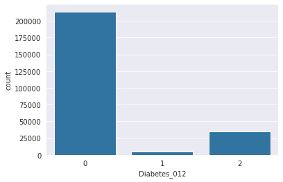

```python
sns.countplot(data=diabetes_df, x='Diabetes_012', color=default_color)
```

##### *Conclusions*

The visualization shows that there is a huge bias in this dataset, as majority of those interviewed do not have diabetes. Few are diabetic and very few are prediabetic.

##### *Question*

What is the distribution of BMI's in the dataset?

##### *Visualization*

Since BMI is a numerical continuous, a histogram will be used to get a sense of it

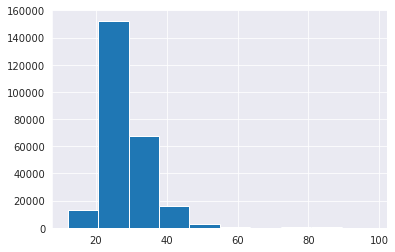

```python
plt.hist(data=diabetes_df, x='BMI')
```

The data appears skewed to the right, while majoirty falls between 20-30. However, the left tail seems to be lost due to the large scale.

It seems necessary to adjust the binsize and zoom into the distribution

I will also include a violinplot and a boxplot

```python
print(diabetes_df.BMI.min(), diabetes_df.BMI.max())
```

```
12.0 98.0
```

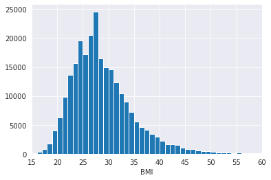

```python
bins = np.arange(diabetes_df.BMI.min(), diabetes_df.BMI.max()+1, 1)
plt.hist(data=diabetes_df, x='BMI', bins=bins);
plt.xlim(15, 60)
plt.xlabel('BMI')
```

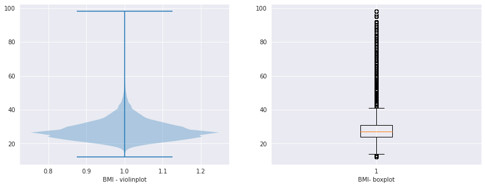

```python
# to add violin and box plots
fig = plt.figure(figsize=(14,5))
ax = plt.subplot(121)
plt.violinplot(diabetes_df.BMI)
plt.xlabel('BMI - violinplot')
ax = plt.subplot(122)
plt.boxplot(data=diabetes_df, x='BMI');
plt.xlabel('BMI- boxplot')
```

##### *Conclusions*

The prior histogram and this violin and boxplots gives a better insight. The distribution of BMI is unimodal but with some skew to the right.

Most BMI's are between 25 and 30, with the majority at about 27, but there are lots of outliers, with BMI's up to almost 100. These must be really obese people and I'll like to further explore to find out how many of these people with extremely high BMI's are actually diabetic.

##### *Question*

HEALTHY BMI or not? Before moving away from BMI, I would like to see the proportion of BMI that falls into each BMI category. To do this, I will engineer a new column to hold classes of BMI, thus:

- \<18.5 = underweight - 1
- 18.5 - 24.9 = healthy - 2
- 25.0 - 29.9 = overweight - 3
- 30.0 - 39.9= obesity - 4
- >=40 = severe obesity

```python
# function to assign BMI category
def categorize_bmi(value):

    """This function takes a BMI value and checks which range it falls in.
    It then returns which category of BMI the given value falls in."""

    if value < 18.5:
        return 1
    elif value>=18.5 and value<=24.9:
        return 2
    elif value>=25.0 and value<=29.9:
        return 3
    elif value>=30.0 and value<=39.9:
        return 4
    elif value>=40.0:
        return 5
```

```python
diabetes_df['BMICategory'] = diabetes_df.BMI.apply(categorize_bmi)
```

```python
# convert this new column into category type
order = diabetes_df.BMICategory.value_counts().index.sort_values()
ordered_var = pd.api.types.CategoricalDtype(ordered=True, categories = order)
diabetes_df.BMICategory = diabetes_df.BMICategory.astype(ordered_var)
```

```python
# check to confirm changes
diabetes_df.info()
diabetes_df.head()
```

```
<class 'pandas.core.frame.DataFrame'>
RangeIndex: 253680 entries, 0 to 253679
Data columns (total 23 columns):
 #   Column                Non-Null Count   Dtype
---  ------                --------------   -----
 0   Diabetes_012          253680 non-null  category
 1   HighBP                253680 non-null  category
 2   HighChol              253680 non-null  category
 3   CholCheck             253680 non-null  category
 4   BMI                   253680 non-null  float64
 5   Smoker                253680 non-null  category
 6   Stroke                253680 non-null  category
 7   HeartDiseaseorAttack  253680 non-null  category
 8   PhysActivity          253680 non-null  category
 9   Fruits                253680 non-null  category
 10  Veggies               253680 non-null  category
 11  HvyAlcoholConsump     253680 non-null  category
 12  AnyHealthcare         253680 non-null  category
 13  NoDocbcCost           253680 non-null  category
 14  GenHlth               253680 non-null  category
 15  MentHlth              253680 non-null  int64
 16  PhysHlth              253680 non-null  int64
 17  DiffWalk              253680 non-null  category
 18  Sex                   253680 non-null  category
 19  Age                   253680 non-null  category
 20  Education             253680 non-null  category
 21  Income                253680 non-null  category
 22  BMICategory           253680 non-null  category
dtypes: category(20), float64(1), int64(2)
memory usage: 10.6 MB
```

|  | Diabetes_012 | HighBP | HighChol | CholCheck | BMI | Smoker | Stroke | HeartDiseaseorAttack | PhysActivity | Fruits | ... | NoDocbcCost | GenHlth | MentHlth | PhysHlth | DiffWalk | Sex | Age | Education | Income | BMICategory |
| --- | --- | --- | --- | --- | --- | --- | --- | --- | --- | --- | --- | --- | --- | --- | --- | --- | --- | --- | --- | --- | --- |
| 0 | 0 | 1 | 1 | 1 | 40.0 | 1 | 0 | 0 | 0 | 0 | ... | 0 | 5 | 18 | 15 | 1 | 0 | 9 | 4 | 3 | 5 |
| 1 | 0 | 0 | 0 | 0 | 25.0 | 1 | 0 | 0 | 1 | 0 | ... | 1 | 3 | 0 | 0 | 0 | 0 | 7 | 6 | 1 | 3 |
| 2 | 0 | 1 | 1 | 1 | 28.0 | 0 | 0 | 0 | 0 | 1 | ... | 1 | 5 | 30 | 30 | 1 | 0 | 9 | 4 | 8 | 3 |
| 3 | 0 | 1 | 0 | 1 | 27.0 | 0 | 0 | 0 | 1 | 1 | ... | 0 | 2 | 0 | 0 | 0 | 0 | 11 | 3 | 6 | 3 |
| 4 | 0 | 1 | 1 | 1 | 24.0 | 0 | 0 | 0 | 1 | 1 | ... | 0 | 2 | 3 | 0 | 0 | 0 | 11 | 5 | 4 | 2 |

5 rows × 23 columns

##### *Visualization*

Now, the BMI category will be visualized with a bar plot

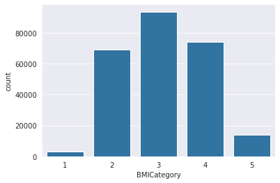

```python
sns.countplot(data=diabetes_df, x='BMICategory', color=default_color);
```

##### *Conclusions*

As suspected, the majority of the BMI in the distribution falls in the overweight range, and the next highest by frequency is obesity, before healthy weight. Also, severely obese people are more than those underweight.

##### *Question*

Exploring mental health and physical health over 30-day period

##### *Visualization*

This will be visualized with a bar chart

```python
diabetes_df.PhysHlth.value_counts()
```

```
0     160052
30     19400
2      14764
1      11388
3       8495
5       7622
10      5595
15      4916
4       4542
7       4538
20      3273
14      2587
25      1336
6       1330
8        809
```

[output cut: 17 more lines]

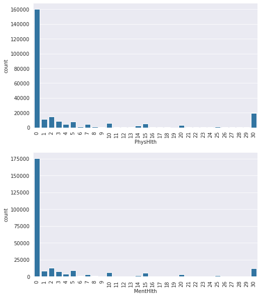

```python
fig, ax = plt.subplots(nrows=2, figsize=(8, 10))

cols = ['PhysHlth', 'MentHlth']
indices = [0,1]

for ind, col in zip(indices, cols):
    axes = sns.countplot(data=diabetes_df, x=col, color=default_color, ax=ax[ind])
    axes.tick_params(axis='x', labelrotation=90)
```

##### *Conclusions*

Both Physical and Mental Health shows that most people report no challenging days in the past 30 days (0 days). There are some values in between, but the next highest is 30 days, and this suggests chronic issues.

The distribution of both variables are very similar, and eyeballing the graphs shows that this is because days 10, 15, 20, 25 and 30 have frequencies, while there seem to be nothing for other days in between. This is probably due to the tendency of people to count and estimate days in 5's.

##### *Question*

What is the distribution of level of education of people in the survey?

##### *Visualization*

As a categorical variable, a bar chart will be appropriate again

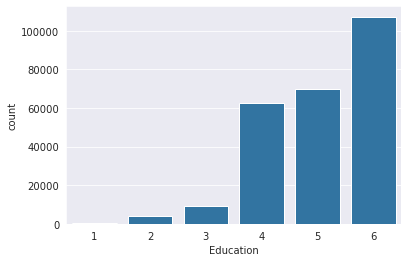

```python
sns.countplot(data=diabetes_df, x='Education', color=default_color)
```

##### *Question*

Explore income similarly

##### *Visualization*

Bar Chart

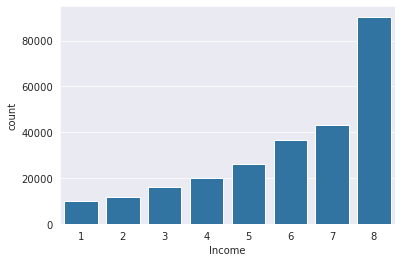

```python
sns.countplot(data=diabetes_df, x='Income', color=default_color)
```

##### *Conclusions*

Similar to the trend in Education, the number of persons with a range of income increases as the income increases. Infact, the people making more than $75,000 (range 8) are more than twice those making the next lower range.

##### *Question*

How do people rate their state of health on the general health scale?

##### *Visualization*

Bar Plot

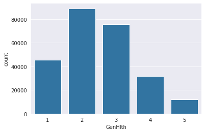

```python
sns.countplot(data=diabetes_df, x='GenHlth', color=default_color)
```

##### *Conclusions*

With 1 being Excellent, most people rate themselves at 2 (Very Good) and the next higest rating being 3 (Good). Relatively few people consider themselves to be in poor health (5)

##### *Question*

What is the age distribution of people in the survey?

##### *Visualization*

Barplot

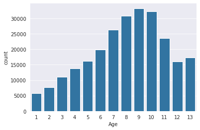

```python
sns.countplot(data=diabetes_df, x='Age', color=default_color)
```

##### *Conclusions*

The distribution of age appears unimodal, with some skew to the left. Much of the people are in the ages 8-10 category (i.e. ages between 55 and 70)

##### *Question*

Are there any interesting properties to the other variables?

##### *Visualization*

These variables are Yes/No questions, and will also be visualized with a bar plot.

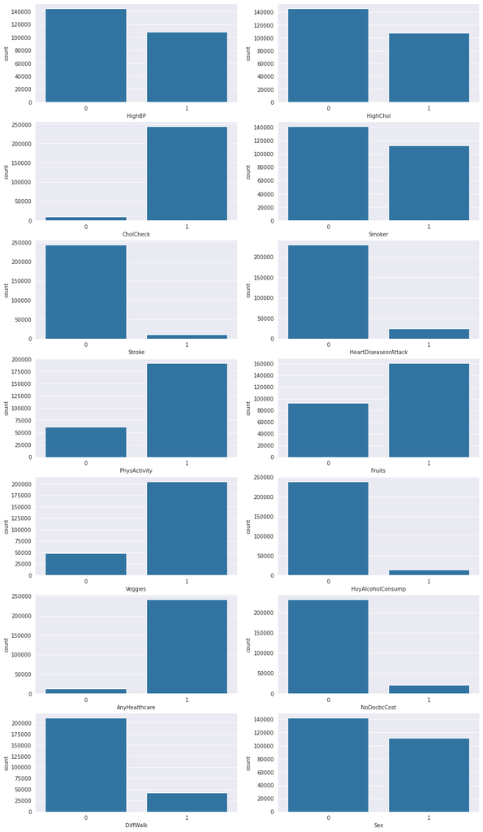

```python
vars_to_plot = ['HighBP', 'HighChol', 'CholCheck', 'Smoker', 'Stroke', 'HeartDiseaseorAttack',
                'PhysActivity', 'Fruits', 'Veggies', 'HvyAlcoholConsump',
                'AnyHealthcare', 'NoDocbcCost', 'DiffWalk', 'Sex']

count = len(vars_to_plot)
cols = 2
rows = int(count/cols)
fig, ax = plt.subplots(nrows=rows, ncols=cols, figsize=(15,28))
plot_no = 0

for i in range(rows):
    for j in range(cols):
        sns.countplot(data=diabetes_df, x=vars_to_plot[plot_no], color=default_color, ax=ax[i][j])
        plot_no+=1
```

##### *Conclusions*

There doesn't seem to be any interesting thing readily apparent from these. However, it might be noteworthy that a good proportion of the population have High Blood Pressure and High Cholesterol

### Discuss the distribution(s) of your variable(s) of interest. Were there any unusual points? Did you need to perform any transformations?

Most interest is in the BMI, and it interesting that the majority of the BMI's recorded are above the healthy limit (healthy BMI ranges between 18.5 and 24.9).

Since the data is preprocessed and much of the variables have been categorized into classes, there were no extreme points that required any form of scaling. Also, the bar plot (using seaborn's countplot) seemed sufficient for most.

### Of the features you investigated, were there any unusual distributions? Did you perform any operations on the data to tidy, adjust, or change the form of the data? If so, why did you do this?

I have converted most of the columns to `category` types since they have been categorized already. Before categorizing, I converted them into type `int` to discard the trailing '.0s' so as to reduce clustering of labels on the plots.

I have also engineered a new column of `BMICategory` to get better insight into the distribution of BMI's in the population involved in the survey.

# Bivariate Exploration

##### *Question*

I will begin Bivariate Explorations with a heatmap of the numerical variables

##### *Visualizations*

```python
diabetes_df.columns
```

```
Index(['Diabetes_012', 'HighBP', 'HighChol', 'CholCheck', 'BMI', 'Smoker',
       'Stroke', 'HeartDiseaseorAttack', 'PhysActivity', 'Fruits', 'Veggies',
       'HvyAlcoholConsump', 'AnyHealthcare', 'NoDocbcCost', 'GenHlth',
       'MentHlth', 'PhysHlth', 'DiffWalk', 'Sex', 'Age', 'Education', 'Income',
       'BMICategory'],
      dtype='object')
```

```python
cols_to_plot = ['Diabetes_012', 'HighChol', 'BMI', 'Smoker',
       'HeartDiseaseorAttack', 'HvyAlcoholConsump', 'GenHlth',
       'Sex', 'Age', 'Education', 'Income', 'BMICategory']
```

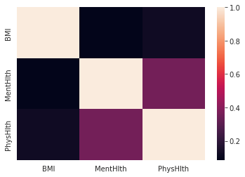

```python
sns.heatmap(diabetes_df.corr())
```

There is no correlation between these variables, though there seem to be some likeness between Physical and Mental Health.

##### *Question*

How do BMI values correlate with diabetes?

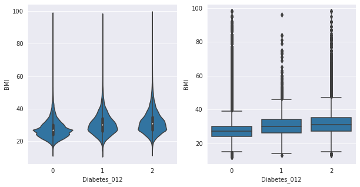

```python
fig = plt.figure(figsize=(10,5))
plt.subplot(121)
sns.violinplot(data=diabetes_df, x='Diabetes_012', y='BMI', color=default_color)
plt.subplot(122)
sns.boxplot(data=diabetes_df, x='Diabetes_012', y='BMI', color=default_color)
```

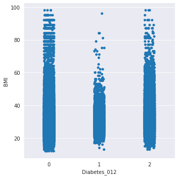

```python
sns.catplot(data=diabetes_df, x='Diabetes_012', y='BMI', color=default_color)
```

This violin and boxplots show that occurence of diabetes is higher with increasing BMI. However, it appears that there are people with high BMI's that are not diabetic (as high as diabetics and even higher than prediabetics).

With the catplot, it becomes apparent that the population of those with the high BMI's without diabetes is even higher than those with diabetes.

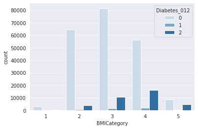

```python
sns.countplot(data=diabetes_df, x='BMICategory', hue='Diabetes_012', palette='Blues')
```

##### *Question*

BMI_class vs Col Check

##### *Visualization*

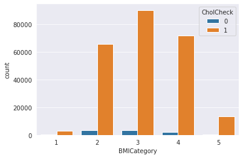

```python
sns.countplot(data=diabetes_df, x='BMICategory', hue='CholCheck')
```

##### *Question*

HighChol vs HeartAttack

##### *Visulization*

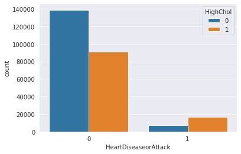

```python
sns.countplot(data=diabetes_df, hue='HighChol', x='HeartDiseaseorAttack')
```

##### *Conclusion*

This clustered bar chart checks the incidence of HighChol with Heart Diseases, and it confirms findings that HighChol increases the risk for heart condiditions. Here, for people who have no heart conditions, about 140,000 have no HighChol, and around 90,000 do. But for people with heart conditions, those with HighChol are more than those without (about 15,000 to 8,000)

##### *Question*

Are people without any form of health coverage are at a risk of not getting health care because of risk?

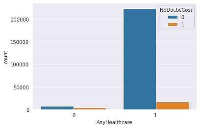

```python
sns.countplot(data=diabetes_df, x='AnyHealthcare', hue='NoDocbcCost')
```

##### *Conclusions*

While there are very few people who have no healthcare coverage or was unable to see the doctor because of cost, it appears that cost wasn't much of a hindrance for people without healthcare to see the doctor. Surprisingly enough, more people with healthcare had instances where they could not see the doctor because of cost.

I will not explore this further as it does not seem to point in anyway toward indication of diabetes.

##### *Question*

What is the distribution of BMI with sex?

##### *Visualization*

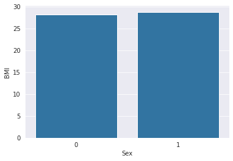

```python
sns.barplot(data=diabetes_df, x='Sex', y='BMI', color=default_color)
```

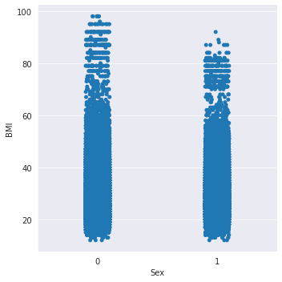

```python
sns.catplot(data=diabetes_df, x='Sex', y='BMI', color=default_color)
```

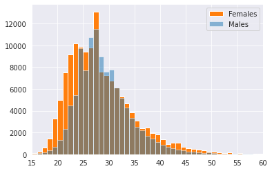

```python
female_BMI = diabetes_df.BMI[diabetes_df.Sex==0]
male_BMI = diabetes_df.BMI[diabetes_df.Sex==1]
bins = np.arange(diabetes_df.BMI.min(), diabetes_df.BMI.max()+1, 1)
plt.hist(x=female_BMI, color=sns.color_palette()[1], bins=bins)
plt.hist(x=male_BMI, color=default_color, alpha=0.5, bins=bins)
plt.xlim(15, 60)
plt.legend(labels=['Females', 'Males'])
```

##### *Conclusions*

I will further explore how this relates with Diabetes diagnosis later

##### *Question*

Diabetes and Sex?

##### *Visualization?*

These are two categorical variables, and I will visualize with clustered bars

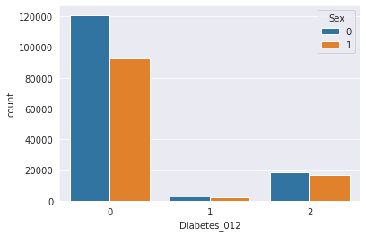

```python
sns.countplot(data=diabetes_df, x='Diabetes_012', hue='Sex')
```

##### *Conclusions*

It appears that there are more females with across each diabetes classification, but this must be because there are more females in the dataset. Thus, this visualization is biased and cannot be used to draw conclusions. A better visualization is needed.

##### *Question*

How do the propotion of the genders in each diabetes class compare?

##### *Visualization*

To do this, I'll need to compute the ratio of males and females for each category of diabetes rating

```python
def get_prop(sex, diab_class):
    """This function calculates the proportion of a particular sex
    that falls into a given diabetes classification"""

    return round((len(diabetes_df.Sex[(diabetes_df.Sex==sex) & (diabetes_df.Diabetes_012==diab_class)]) / \
    len(diabetes_df.Sex[diabetes_df.Sex==sex])) * 100, 2)
```

```python
# build two dictionaries to hold each proportions for each gender.
# This is necessary because of the visualization that will follow

female_props_dict = {}
male_props_dict = {}

prefixes = ['no_', 'pre_', '']
genders = ['female', 'male']
for i in range(3):  # loop runs three times, once for each diabetes class
    for j in range(2):  # loop runs twice, once for each sex
        if j==0:
            female_props_dict[f'{prefixes[i]}diab_{genders[j]}_prop'] = get_prop(j, i)
        else:
            male_props_dict[f'{prefixes[i]}diab_{genders[j]}_prop'] = get_prop(j, i)



print(male_props_dict)
print(female_props_dict)
```

```
{'no_diab_male_prop': 83.03, 'pre_diab_male_prop': 1.81, 'diab_male_prop': 15.16}
{'no_diab_female_prop': 85.2, 'pre_diab_female_prop': 1.83, 'diab_female_prop': 12.97}
```

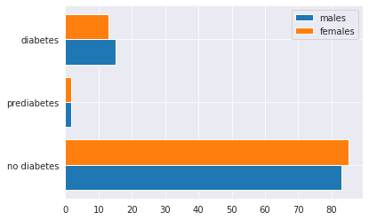

```python
y=np.arange(len(female_props_dict))
plt.barh(y=y-0.2, height=0.4, width=male_props_dict.values())
plt.barh(y=y+0.2, height=0.4, width=female_props_dict.values())
plt.yticks(y, ['no diabetes', 'prediabetes', 'diabetes']);
plt.legend(['males', 'females'])
```

This is a much cleared visualization. As opposed to the earlier misleading plot, this shows that there are more diabetic males. In contrast, the proportion of females without diabetes is higher than than the males.

##### *Question*

BMI Categories by Sex?

##### *Visualization*

As these are both categorical, a clustered barplot will be used again.

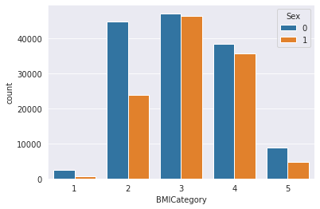

```python
sns.countplot(data=diabetes_df, x='BMICategory', hue='Sex')
```

##### *Conclusions*

There is nothing interesting here that has not shown up before. The distribution of BMI's follow a similar pattern in both genders.

However, there seems to be a huge disparity in the Healthy weight category between males and females, with males being almost underrespresented in this category.

##### *Question*

How does BMI distribution vary with age?

##### *Visualization*

For this Qualitative vs Quantitative plot, I'll begin with a barplot of the means for each age category, then follow with a catplot

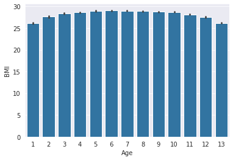

```python
sns.barplot(data=diabetes_df, x='Age', y='BMI', color=default_color)
```

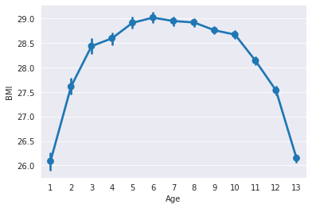

```python
sns.pointplot(data=diabetes_df, x='Age', y='BMI', color=default_color, jitter=True)
```

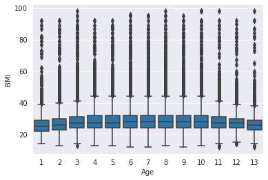

```python
sns.boxplot(data=diabetes_df, x='Age', y='BMI', color=default_color)
```

From this dataset, BMI does not seem to vary very much as the ages categories increase, except for a slight tapering on each end of the age categories.

##### *Question*

Next, I want to compare these ages with the BMI categories

##### *Visualization*

These are both categorical, and I will employ a clustered bar chart

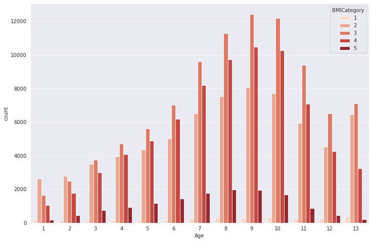

```python
fig = plt.figure(figsize=(12,8))
sns.countplot(data=diabetes_df, x='Age', hue='BMICategory', palette='Reds')
```

##### *Conclusions*

At the younger ages, there are more people in the Healthy Weight category (2) than the others, but with increasing age, the proportion of Overweight persons increase, as does the Obese and Extremely Obese people.

##### *Question*

How does diabetes vary with age?

##### *Visualization*

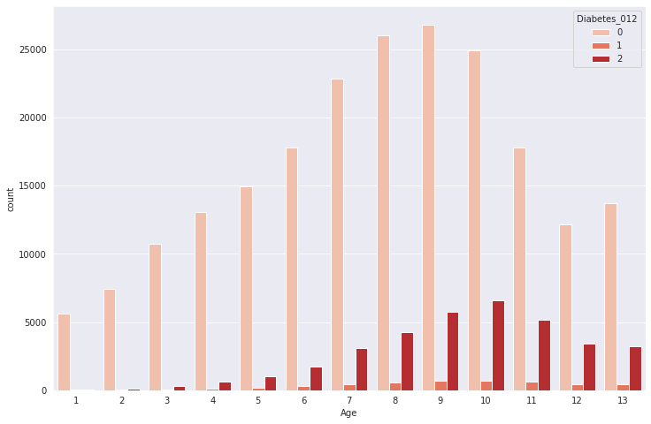

```python
fig = plt.figure(figsize=(12,8))
sns.countplot(data=diabetes_df, x='Age', hue='Diabetes_012', palette='Reds')
```

Here, it is clear that the number of diabetic persons increase with age, but then tapers off in the more advanced ages. The occurence of diabetes is highest in the age 10 category (65-69)

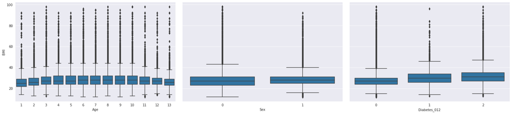

```python
def boxgrid(x, y, **kwargs):
    """ Quick hack for creating box plots with seaborn's PairGrid. """
    default_color = sns.color_palette()[0]
    sns.boxplot(x=x, y=y, color=default_color)


plt.figure(figsize = [10, 10])
g = sns.PairGrid(data = diabetes_df, x_vars = ['Age', 'Sex', 'Diabetes_012'], y_vars = ['BMI'],
                height = 5, aspect = 1.5)
g.map(boxgrid)
plt.show();
```

The above only summarizes the trends so far

##### *Question*

Do people who consume alcohol heavily have higher BMI's?

##### *Visualization*

I will use a bar plot, catplot to get insights

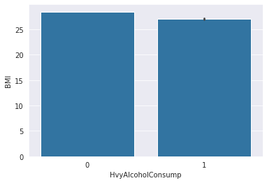

```python
sns.barplot(data=diabetes_df, x='HvyAlcoholConsump', y='BMI', color=default_color)
```

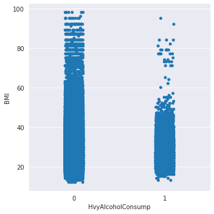

```python
sns.catplot(data=diabetes_df, x='HvyAlcoholConsump', y='BMI', color=default_color)
```

##### *Conclusions*

The two plots show that Alcohol consumption does not increase BMI. In fact, those without heavy alcohol consumption in this survey have higher BMI's than those who consume alcohol.

##### *Question*

Finally, I'm curious about those who have difficulty walking. Perhaps there's a link between BMI's and difficulty walking?

##### *Visualization*

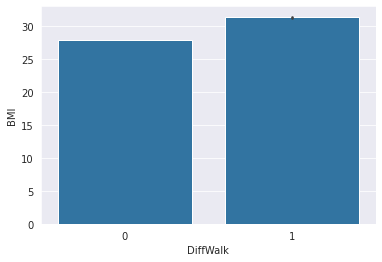

```python
sns.barplot(data=diabetes_df, x='DiffWalk', y='BMI', color=default_color)
```

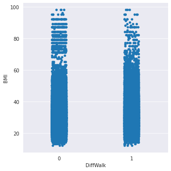

```python
sns.catplot(data=diabetes_df, x='DiffWalk', y='BMI', color=default_color, jitter=True)
```

Though the inital barplot shows higher BMI for people who have difficulty walking, it is impossible to conclude, as weight is not the only factor that contributes to difficulty walking.

The catplot certainly does not confirm that difficulty walking means higher BMI.

### Talk about some of the relationships you observed in this part of the investigation. How did the feature(s) of interest vary with other features in the dataset?

There are several interesting features that came out during the visualziations. My suspicion of chances of diabetes increasing with BMI is getting confirmed. However, I also find it interesting that some people with extremely high BMI's are not diabetic, suggesting that BMI, though an indicator, is not an absolute measure for diabetes. Other factors are in play.

The other interesting point is in sex distribution compared with diabetes class. It appears that there are more diabetic males than females, but vice versa for no diabets and prediabetes.

Also, there is a surprisingly low number of men with healthy weight compared with females.

The later plots exploring age with other variables of interest shows that BMI and the risk of diabetes increses with age, with some tapering towards the more advanced ages.

I also confirmed that high cholesterol does increase the chances of heart pathologies.

# Multivariate Exploration

This Multivariate Exploration section will focus on further relationships between Diabetes, BMI, Sex and Age.

##### *Question*

How does Diabetes category vary with BMI and Age?

##### *Visualization*

This is a plot of one numerical variable against two categorical variables.

I will visualize wit a lineplot of BMI against Age, and separated by Diabetes class

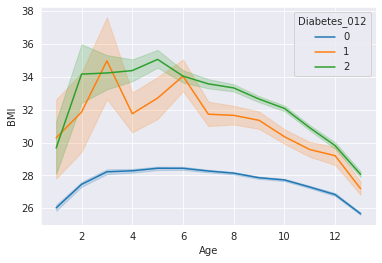

```python
sns.lineplot(data=diabetes_df, y='BMI', x='Age', hue='Diabetes_012')
```

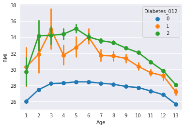

```python
# pointplot
sns.pointplot(data=diabetes_df, y='BMI', x='Age', hue='Diabetes_012')
```

##### *Conclusions*

The trend of increasing BMI with age, then tapering off at advanced ages is still seen here, but it's split based on Diabetes classes in this 3D plot.

This plot shows that for those without diabetes, the BMI never rises as high as any of the other two BMI classes (prediabetes and diabetes). Therefore, we can conclude that keeping a healthy BMI keeps is a safe way to avoid diabetes.

On the other hand, diabetics have the highest BMI levels, with that of prediabetics being lower and only overlapping at a few points.

##### *Question*

Relate Diabetes with Sex and BMI

##### *Visualization*

This is a plot of one numerical variable against two categorical variables.

Visualization will be done with a barplot of the BMI (average values) against sex, and separated into Diabetes classes (the main target variable)

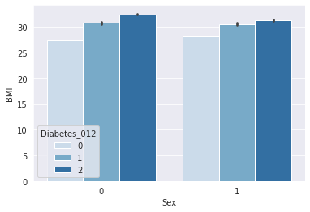

```python
sns.barplot(data=diabetes_df, x='Sex', y='BMI', hue='Diabetes_012', palette='Blues')
```

##### *Conclusions*

The average BMI increases consistently from non-diabetic to prediabetic to diabetic for both sexes. This further confirms that higher BMI is higher risk for diabetes.

##### *Question*

Relate Diabetes with Sex and Age

##### *Visualization*

This is a plot of three cateogrical variables

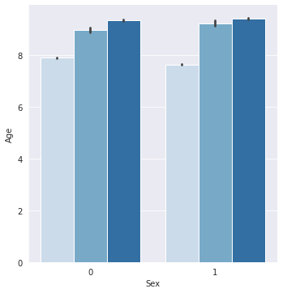

```python
try:
    sns.catplot(data=diabetes_df, x='Sex', y=diabetes_df.Age.astype(float), hue='Diabetes_012', \
                palette='Blues', kind='bar')
except ValueError:
    pass
```

##### *Conclusion*

This further shows that at the higher Ages, chances of prediabetes and diabetes increase accordingly.

##### *Question*

Relate BMI with Sex and Age

##### *Visualization*

This is relating one numerical with two categorical variables

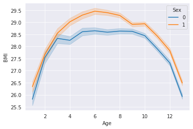

```python
sns.lineplot(data=diabetes_df, y='BMI', x='Age', hue='Sex')
```

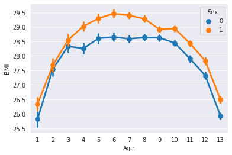

```python
sns.pointplot(data=diabetes_df, y='BMI', x='Age', hue='Sex')
```

##### *Conclusions*

BMI increases and then decreases with increasing age.

Also, these line plots reveal an interesting insight. Earlier, Bivariate explorations showed that more women have higher BMI's than men, but when compared by age groups, women of the same age group have consistently lower BMI's than the males of the same age group.

##### *Question*

Are there any interesting relationships when all four variables are plotted together?

##### *Visualization*

This will be a series of 4D plots of 1 numerical variable against 3 categorical variables.

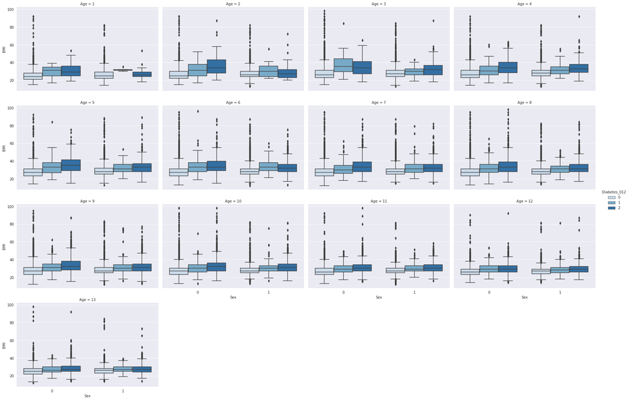

```python
g = sns.catplot(data=diabetes_df, x='Sex', y='BMI', hue='Diabetes_012', col='Age', \
                height=4, aspect=1.5, kind='box', col_wrap=4, palette='Blues')
```

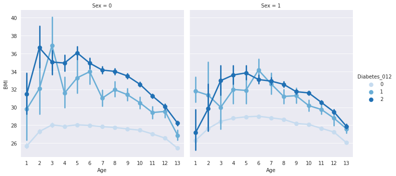

```python
g = sns.catplot(data=diabetes_df, x='Age', y='BMI', hue='Diabetes_012', col='Sex', \
                kind='point', palette='Blues')
```

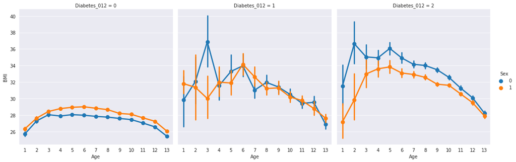

```python
g = sns.catplot(data=diabetes_df, x='Age', y='BMI', col='Diabetes_012', hue='Sex', \
                kind='point')
```

##### *Conclusions*

The first 4D-pointplot directly comparing Diabetes classes for each gender shows a clearer trend, and further strengthens the earlier insights. BMI for non-diabetics is still consistently lower across all the ages, while that for diabetics is higher, except for ocassional points where the average BMI for prediabetics is higher than for diabetics.

The last pointplot is a variation of the first, but this time there is a more direct comparision between the Sexes for each Diabetes class, which reveals an interesting insight not before seen.

- For non-diabetics, the BMI of the males is consistently higher than that of the females.
- For prediabetics, average BMI is about the same, except for a huge spike in BMI's of females at about age category 3. This is the category for ages 25-29, and perhaps this jarring spike in BMI's can be traced to pregnancy and childbirth?
- In the diabetic plot column, the trend is reversed compared with non-diabetic. Now, diabetic women have consistently higher BMI's than diabetic men.

### Talk about some of the relationships you observed in this part of the investigation. Were there features that strengthened each other in terms of looking at your feature(s) of interest?

Certainly, these variable, considered together, strengthen each other. These plots have severally shown that the risk of Diabetes increases with Age and BMI, and males have a slightly higher risk, though this cannot be definitely concluded from this visualizations.

# Conclusions

I have taken several variables from the dataset through several variations of visualizations in this Exploratory Visualization process, including Univariate, Bivariate and Multivariate Visualizations.

The main target variable was the `Diabetes_012` column, which classified patients into 3: (0 for non-diabetic, 1 for prediabetic, and 2 for diabetic).

While there were many interesting insights gathered along the course of the visualizations, my primary interest was in determining the indicators for diabetes in the dataset, focusing on BMI, Age, and Sex. I can conclude that BMI and Age are indicators for Diabetes.

Note, however, that I have used the term, 'indicators', because these are in no way absolute yardsticks. There are many other factors that have not been considered in this exploration, but there is enough to confirm that the variables in question are indicators for Diabetes.

```python
# save the dataset
diabetes_df.to_csv('data/diabetes_processed.csv', index=False)
```

> (c)2022 EBENEZER MARADESA